# Week 13: Publication quality statistical graphics using ggplot2

Wednesday, April 14, 2021 @ 1:30 PM HST

## Goals

- Identify limitations of default **ggplot2** graphics
- Use mathematical annotations and the **scales** package to add measurement units and customize axis text
- Annotate a plot with quantitative information
- Add confidence intervals and ribbons

### Getting started

**Note**: Same instructions as the last two weeks, just change everything from “lab02” to “lab13”

1. We have set a class Workspace called biol220-lab13. Join the Workspace by clicking on the following link (you only need to do this once; after today you’ll automatically have access).

https://rstudio.cloud/spaces/136532/join?access_code=lnYSMjcUlfvPlg9l%2BOW%2F0ZvQbsaAG%2FI2GuDDIrU5

**Important**: Make sure you register using your userid@hawaii.edu account, not a personal gmail account. If you accidentally, use your personal account, let me know. I will delete it while you register with the university account.

Each item listed under “All Projects” is a “Project” within the biol220-lab13 Workspace. Each week I will create a Project template that you will copy and work from (you cannot edit the original).

3. To create your own, click “START” to the left of “lab13”. Next week, it’ll be “lab14”, then “lab15”, etc.

4. Once the Project is copied and deployed, rename the Project from “lab13” to include your name like this:

“lab13-muir-chris”

## Learning the Tools

In this lab you’ll learn some of key concepts for making compelling, informative statistical graphics using the *R* package **ggplot2**.

**ggplot2** plots are built up in layers, maybe in several steps. You can plot the data, then overlay a summary (for instance, a regression line or smoother), and then add any metadata and annotations you need.

We’ll start with an OK plot, then learn how to add elements (measurement units, regression lines, confidence intervals, and parameter estimates) to make it a publication quality figure.

### Getting started

Make on OK plot that needs work using the built-in `iris` data set. Use `ggplot()` and `geom_point()` functions to make a scatter plot of “Petal.Length” against “Sepal.Length”. Your figure should look like this:

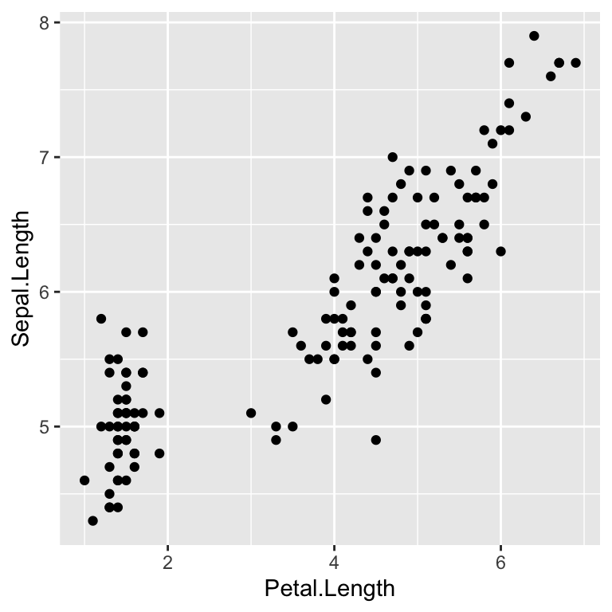

We see a basic scatter plot with petal length ($x$-axis) plotted against ($y$-axis) for three species of *Iris*.

Type `iris` into the command prompt to print the entire data set. Scroll through the data to refresh yourself on its content.

Now, let’s review the principles of good graphics to find ways to improve this plot.

#### Principle 1 - Show the data.

How does this plot fail to show the data?

- it does not include all variables in the data
- it does not show which data belong to which *Iris* species
- it shows all data just fine

Unhide to see answer

**Answer**

Correct Answer: it does not show which data belong to which *Iris* species

It is OK if you do not plot all variables in a data set, depending on what you are trying to show. In this case, species differences in floral morphology are very important and this should be visually clear.

Improve the plot by modifying the OK plot to use a different color for each Species. Don’t worry about the adjusting the color palette for now, just use the default. You figure should look like this:

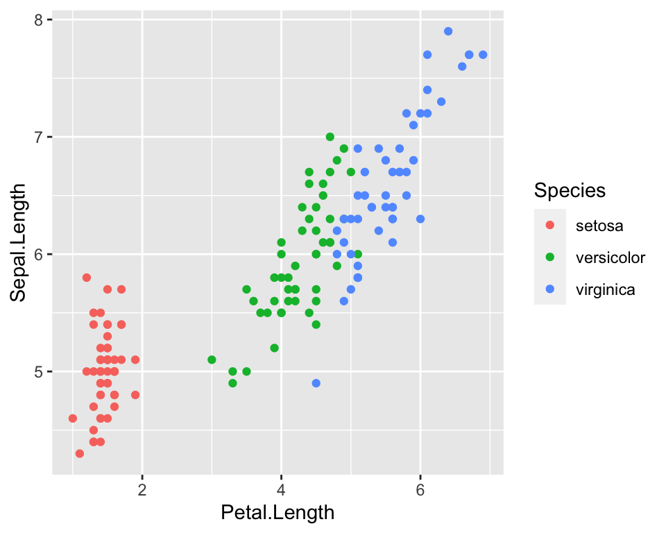

#### Principle 2 - Make patterns in the data easy to see.

How does this plot fail to make patterns in the data easy to see?

- axis scales are inappropriate
- it’s cluttered with chart junk
- patterns are easy to see

Unhide to see answer

**Answer**

Correct Answer: patterns are easy to see

The main patterns are that petal length and sepal are positively related, but their values differ between *Iris.* Since we’ve added color to distinguish species, these patterns are relatively easy to see in this plot.plot

#### Principle 3 - Represent magnitudes honestly

How does this plot fail to represent magnitudes honestly?

- the baseline is not at zero
- 3-D embellishments distort magnitudes
- magnitudes are represented honestly

Unhide to see answer

**Answer**

Correct Answer: magnitudes are represented honestly

The magnitudes are represented honestly. We wouldn’t want to start at a baseline of zero for a scatter plot, since we want to see relative differences in floral size between species and correlation between floral parts.

#### Principle 4 - Draw graphical elements clearly.

How does this plot fail to draw graphical elements clearly?

- measurement units are not labeled
- typeface is hard to read
- all graphical elements are clear

Unhide to see answer

**Answer**

Correct Answer: measurement units are not labeled

The measurement units are not labeled! Is it mm, cm, inches? Unless you are very familiar with *Iris* species, it is hard to tell. In the next section, we will introduce adding measurement units to the axes. The simple, sans-serif font is not fancy, but highly legible.

### Adding measurement units and customizing axis text

In this section, you will add units to your axis labels in **ggplot2** using text and mathematical annotation. First, let’s recreate the OK figure we made in the section above and assign it the name `ok_figure` like this:

```r
ok_figure <- ggplot(iris, aes(Petal.Length, Sepal.Length, color = Species)) +
  geom_point()
```

For simple units, like centimeters in this case, you can just change the labels by layering on custom `xlab("x-axis title")` and `ylab("y-axis title")`.

Add custom axis labels to your plot `ok_figure`. The $x$-axis label should read “Petal length (cm)” and the $y$-axis label should read “Sepal length (cm)”. Your figure should look like this:

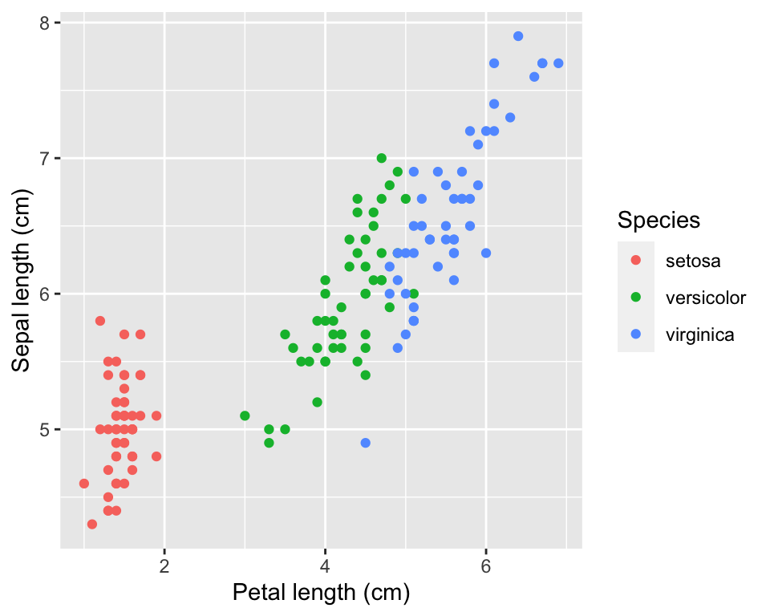

Just for illustration, we will modify the $x$ label to show you how to do some other common units. These are more complex and use mathematical annotation techniques. You can read more detail about mathematical annotation in R by executing:

```r
?plotmath
```

First, we have to change our label from text in quotes to `expression()`, which has some odd syntax. You can create the same $x$ label as before using `ok_figure + xlab(expression(Petal~length~(cm)))`. Try it out on your own. Notice that with expressions there are no quotes, instead of spaces we used `~`.

Next, modify the expression to be in units of cm$^2$ Read the the `plotmath` help page (`?plotmath`) to see how to do it. It should look like:

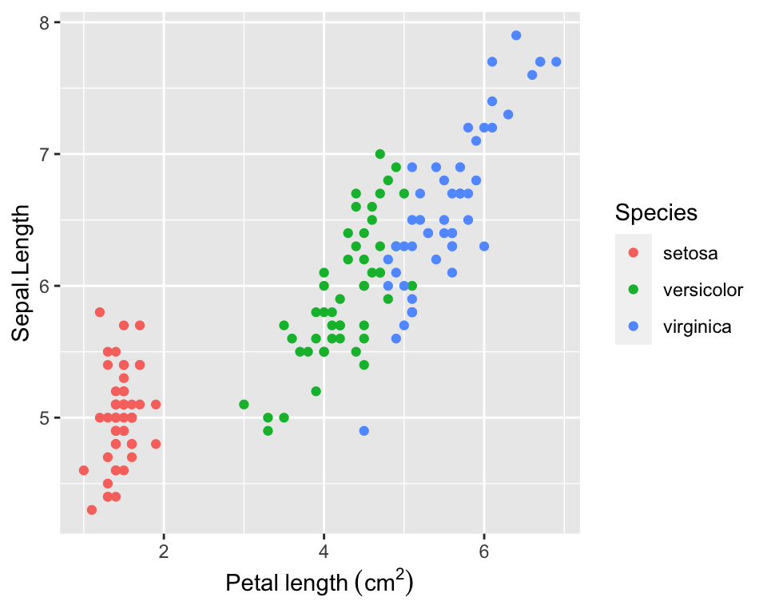

Hint: use the `^` symbol to make an exponent

Next, imagine we were plotting units of acceleration, $\frac{m}{s^2}$. In general, to plot $x$ over $y$, use `frac(x,y)`. Use this rule to modify the previous label, except with units $\frac{m}{s^2}$ like this:

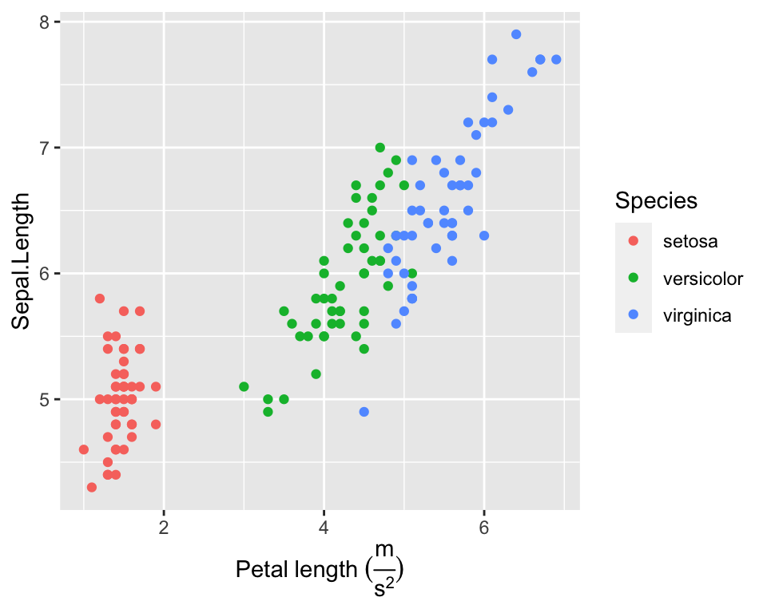

In this example, you combined the exponent (`s^2`) with the new function `frac()` to make a more complex measurement unit.

One annoying thing is that the parentheses stay small rather than scaling with the units. Fixing this is not intuitive. Use the expression `Petal~length~bgroup("(", frac(m,s^2), ")")` to have scalable parentheses around the units

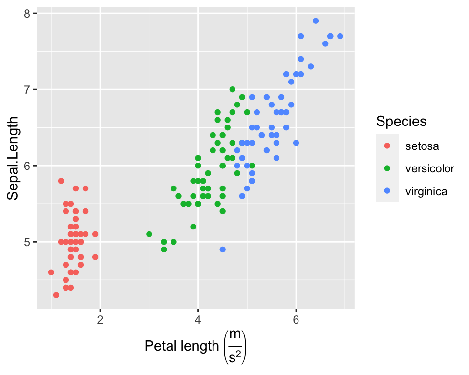

Finally, we’ll learn to label times properly. I don’t explain everything here, but this code could be useful for your final project. You’ll need to load the **lubridate** and **scales** packages, as well as **readr** and **dplyr** like usual.

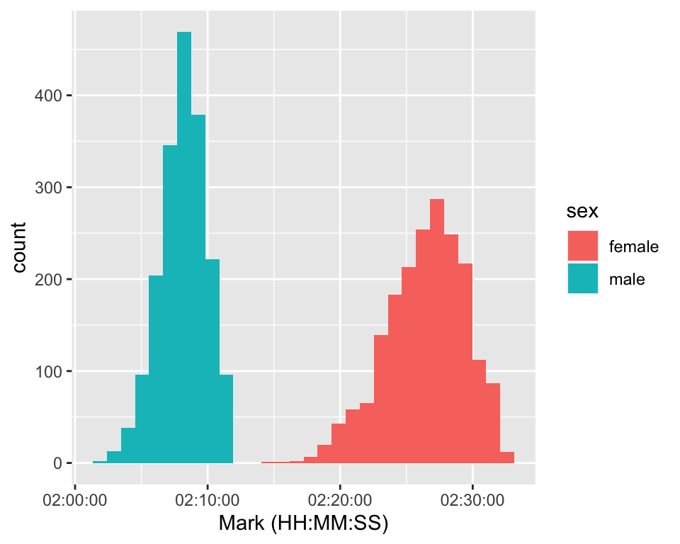

```r
library(dplyr)
library(lubridate)
library(readr)
library(scales)

world_athletics_data <- read_rds("data/world-athletics-data.rds") %>%
  filter(event == "marathon") %>%
  mutate(mark_datetime = as_datetime(mark))

ggplot(world_athletics_data, aes(mark_datetime, fill = sex)) +
  geom_histogram(bins = 30) +
  scale_x_datetime(labels = label_time("%H:%M:%S")) +
  xlab("Mark (HH:MM:SS)")
```

### Linear regression lines and confidence ribbons

First, let’s save our progress by calling the figure we made above `better_figure`:

```r
better_figure <- ok_figure +
  xlab("Petal length (cm)") +
  ylab("Sepal length (cm)")
```

We’ll learn the details of linear regression soon. Suffice to say, linear regression is used when we want to predict a response variable from an explanatory variable. **ggplot2** makes it easy to add regression lines and confidence ribbons, but make sure you know what it means how to interpret them before adding them to your figures in a presetnation or report.

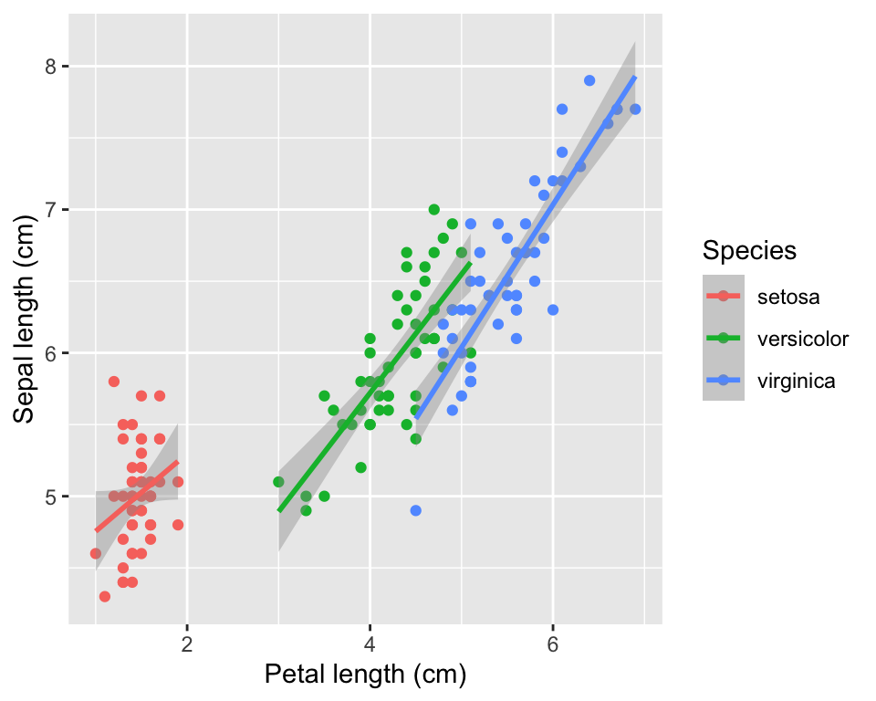

```r
better_figure +
  geom_smooth(method = "lm", level = 0.95)
```

`geom_smooth()` plots a line to predict Sepal Length from Petal Length. The `method = "lm"` argument tells it to use a **l**inear **m**odel (linear regression is one case of linear models). The `level = 0.95` tells it to plot 95% confidence ribbons, the gray polygons around the lines. These ribbons tell us the plausible range of relationships between our variables. Notice how **ggplot2** effortlessly applies the linear regression to all three *Iris* species because we’ve already grouped the species by using `color = Species` within the `aes()` function.

### ANOVA and connecting letters

I don’t explain all the details here, but this example might be useful if you are using ANOVA for your final project. First, let’s do an ANOVA on Species and Petal.Length:

```r
iris_lm <- lm(Petal.Length ~ Species, data = iris)
anova(iris_lm)
```

|  | Df | Sum Sq | Mean Sq | F value | Pr(>F) |
| --- | --- | --- | --- | --- | --- |
| Species | 2 | 437.1028 | 218.5514000 | 1180.161 | 2.856777e-91 |
| Residuals | 147 | 27.2226 | 0.1851878 | NA | NA |

Clearly, we can reject the null hypothesis that the mean petal length is the same in each species. Next, we’ll use `TukeyHSD()` to see which species pairs differ. Annoyingly, you have to use the `aov()` function on `iris_lm` for this to work:

```r
TukeyHSD(aov(iris_lm))
```

```
##   Tukey multiple comparisons of means
##     95% family-wise confidence level
##
## Fit: aov(formula = iris_lm)
##
## $Species
##                       diff     lwr     upr p adj
## versicolor-setosa    2.798 2.59422 3.00178     0
## virginica-setosa     4.090 3.88622 4.29378     0
## virginica-versicolor 1.292 1.08822 1.49578     0
```

The table shows that all species pairs are significantly different. How do we show that graphically? A common way is using connecting letters. Two groups that have same letter not significantly different; groups that are different have different letters. Since all our pairs are different, they each get their own letter, A, B, C. First let’s just make a box plot, then add the connecting letters.

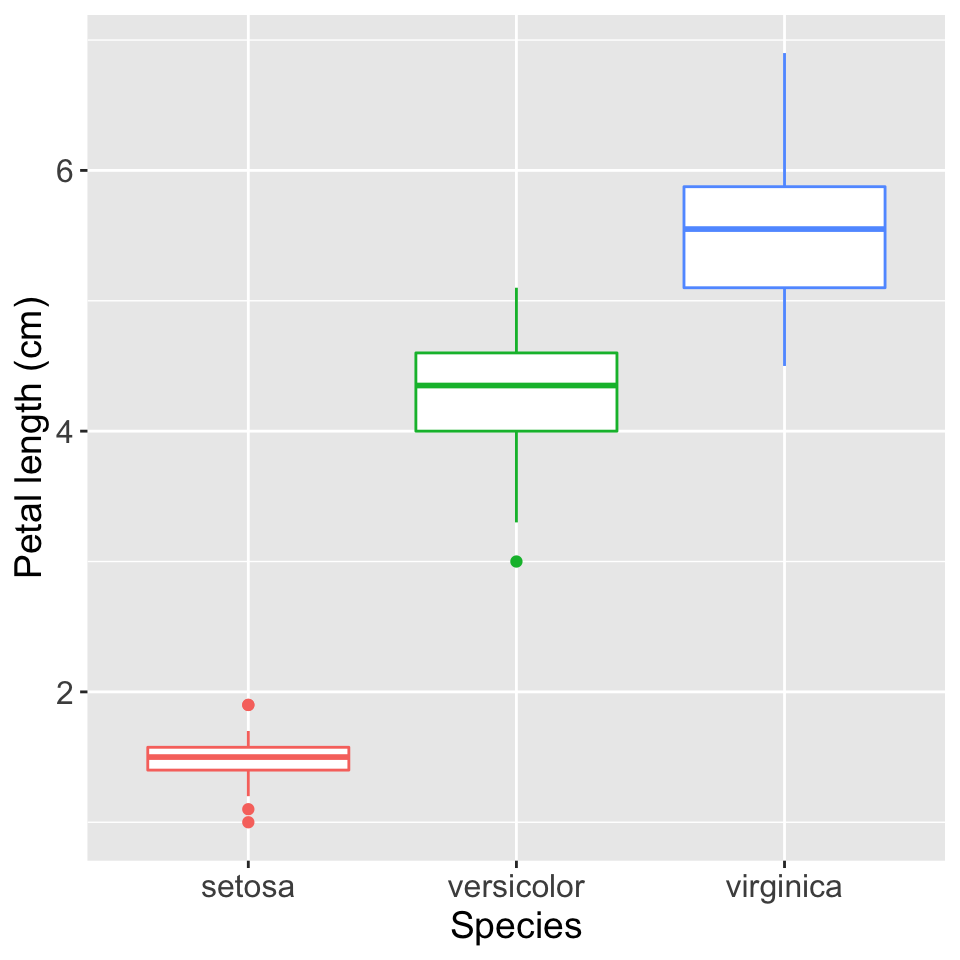

```r
anova_figure <- ggplot(iris, aes(Species, Petal.Length, color = Species)) +
  stat_boxplot(show.legend = FALSE) +
  ylab("Petal length (cm)") +
  theme(
    axis.text = element_text(size = 12),
    axis.title = element_text(size = 14)
  )

anova_figure
```

There is no simple way to add connecting letters using `geom_text()`. Here is one approach. This code `summarize(Petal.Length = max(Petal.Length))` positions the letter above the highest value for each species.

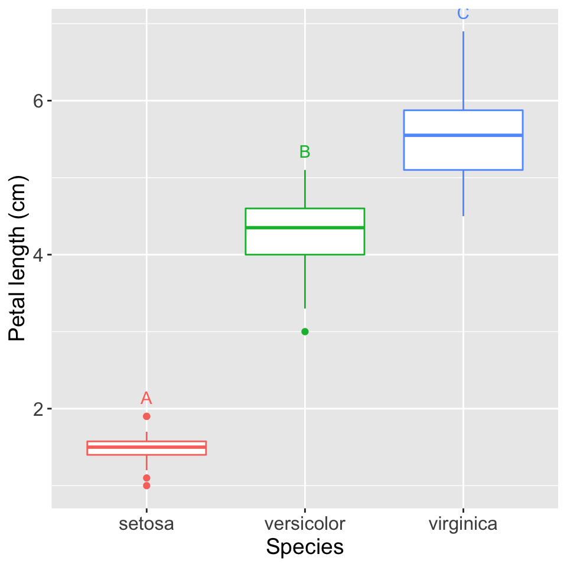

```r
# Use group_by and summarize to make new data for plotting letters
iris_text <- iris %>%
  group_by(Species) %>%
  summarize(Petal.Length = max(Petal.Length)) %>%
  mutate(letter = c("A", "B", "C"))

anova_figure +
  geom_text(data = iris_text, mapping = aes(label = letter),
            vjust = -1, show.legend = FALSE)
```

Here’s another set of tricks to plot mean, standard error, points, and connecting letters. I use Sepal.Length in this example because it’s easier to see error bars.

```r
iris_lm1 <- lm(Sepal.Length ~ Species, data = iris)
anova(iris_lm1)
```

|  | Df | Sum Sq | Mean Sq | F value | Pr(>F) |
| --- | --- | --- | --- | --- | --- |
| Species | 2 | 63.21213 | 31.6060667 | 119.2645 | 1.669669e-31 |
| Residuals | 147 | 38.95620 | 0.2650082 | NA | NA |

```r
TukeyHSD(aov(iris_lm1))
```

```
##   Tukey multiple comparisons of means
##     95% family-wise confidence level
##
## Fit: aov(formula = iris_lm1)
##
## $Species
##                       diff       lwr       upr p adj
## versicolor-setosa    0.930 0.6862273 1.1737727     0
## virginica-setosa     1.582 1.3382273 1.8257727     0
## virginica-versicolor 0.652 0.4082273 0.8957727     0
```

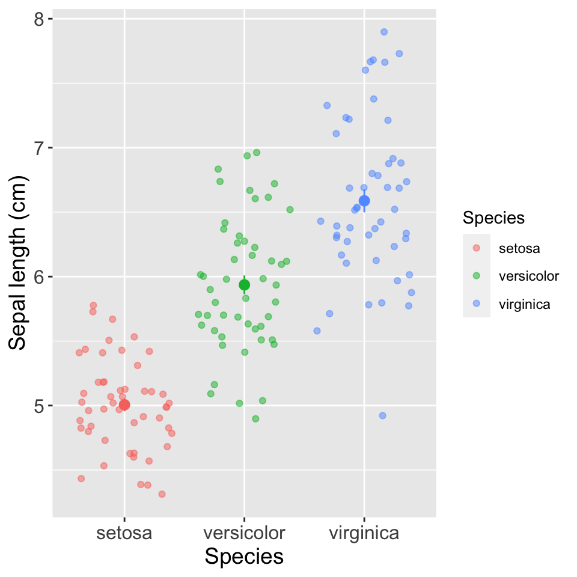

```r
anova_figure1 <- ggplot(iris, aes(Species, Sepal.Length, color = Species)) +
  geom_jitter(alpha = 0.5) +
  stat_summary(fun.data = mean_se, show.legend = FALSE) +
  ylab("Sepal length (cm)") +
  theme(
    axis.text = element_text(size = 12),
    axis.title = element_text(size = 14)
  )

anova_figure1
```

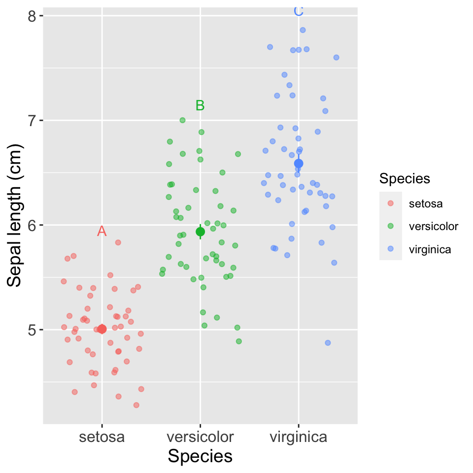

```r
iris_text1 <- iris %>%
  group_by(Species) %>%
  summarize(Sepal.Length = max(Sepal.Length)) %>%
  mutate(letter = c("A", "B", "C"))

anova_figure1 +
  geom_text(data = iris_text1, mapping = aes(label = letter),
            vjust = -1, show.legend = FALSE)
```

## Questions

### 1. Cuckoo eggs

Revisit the Cuckoo eggs data set from Lab 12, Question 1. The data file “cuckooeggs.csv” contains data on the lengths of cuckoo eggs laid in the nests of a variety of host species. Here we compare the mean size of cuckoo eggs found in the nests of different host species. In part e. you decided which species pairs were significantly different using a Tukey-Kramer test. Plot the data again following the example above wih *Iris* sepal length. Plot the points (use `geom_jitter()`), mean with error bars (use `stat_summary()`), and connecting letters assuming $\alpha = 0.05$ (use `geom_text()`). Some of these groups are not significantly different, so should get the same letter.

For example, consider three species Meadow Pipit, Pie Wagtail, and Hedge Sparrow. Meadow Pipit-Hedge Sparrow are significantly different, Pied Wagtail-Hedge Sparrow are NOT significant different, and Pied Wagtail-Meadow Pipit are NOT significantly different. For these three species, the connecting letters would therefore be:

| Host species | Mean egg length | Letter |
| --- | --- | --- |
| Meadow Pipit | 22.3 | A |
| Pie Wagtail | 22.9 | AB |
| Hedge Sparrow | 23.1 | B |